# Kaggle Titanic using penalized logistic regression

### Dimension reduction

tSNE, t-distributed stochastic neighborhood embedding

Lets look at some variables in 2D to see if anything separates well

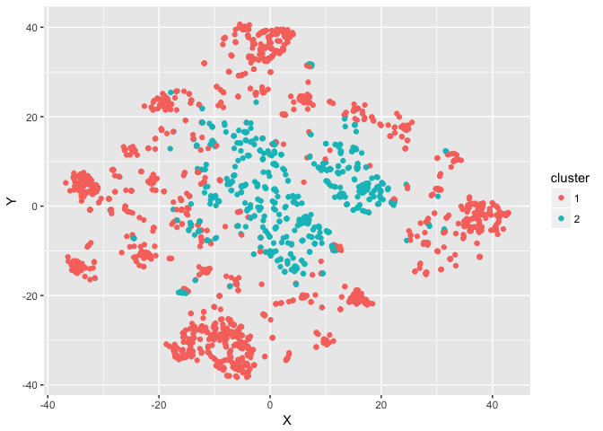

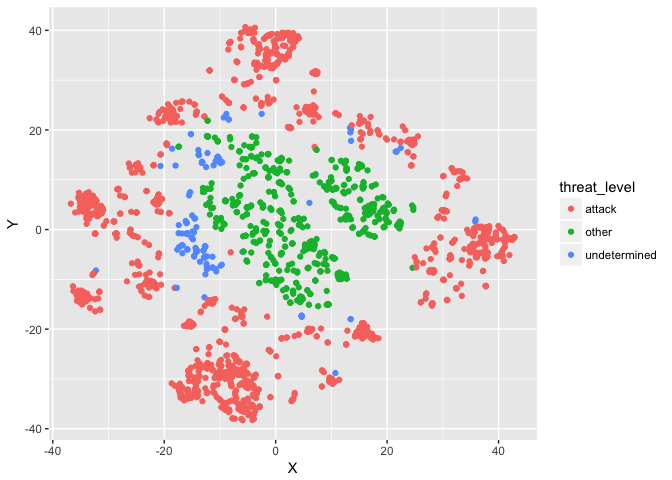

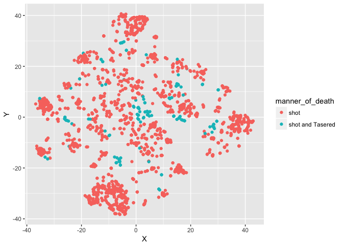

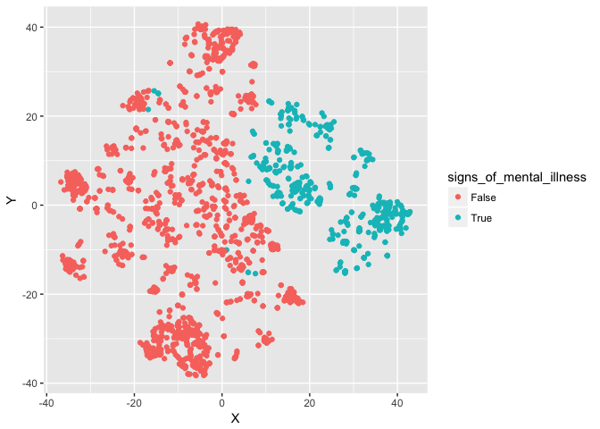

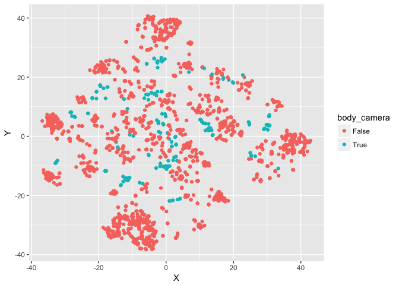

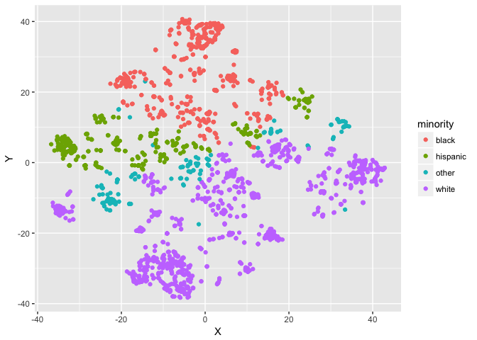

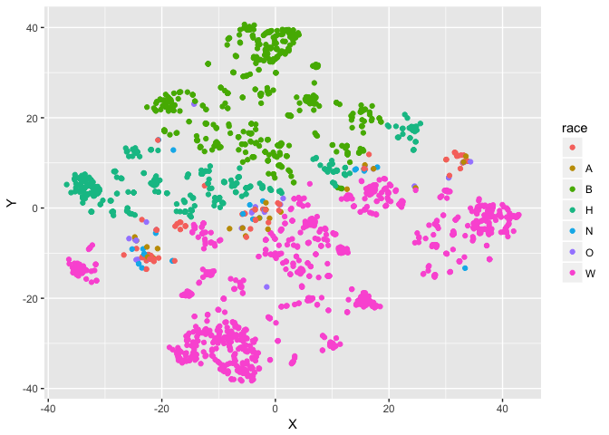

Can compare with MDS MDS

Plot MDS without coloring groups

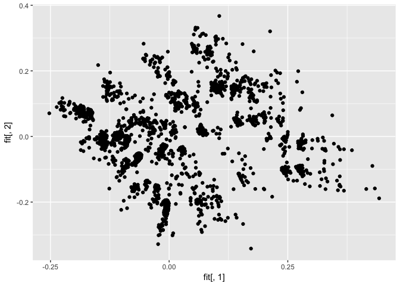

Plot MDS, color by cluster

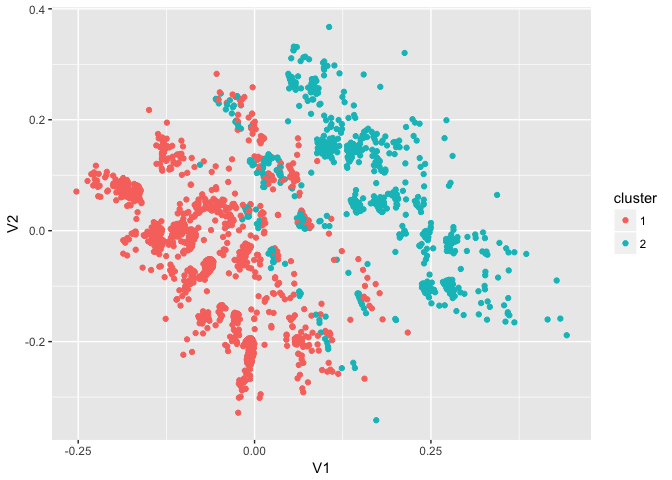

## Zoe

eliminate the rows with missing entries

discretize weapons

### CLASSICAL MDS -- GET DISTANCES BETWEEN PEOPLE

Gower distance Euclidean distance doesn't make sense for categorical data

try three dimensions

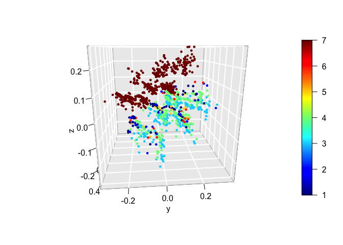

try two dimensions

plain MDS plot

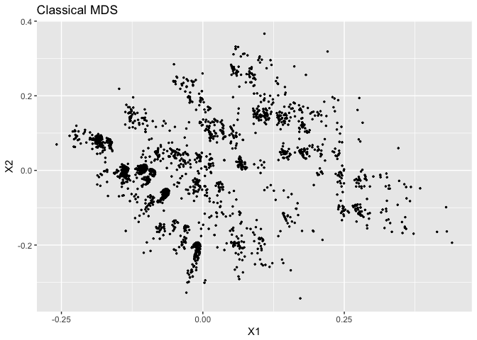

colored by mental illness

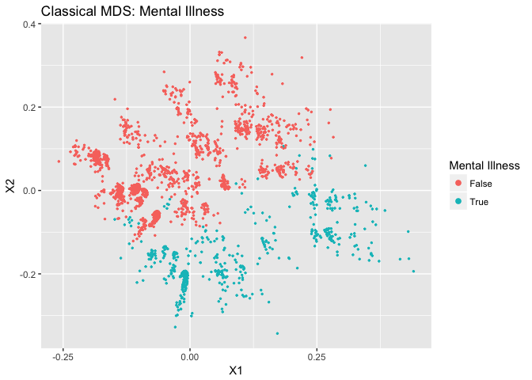

colored by threat level

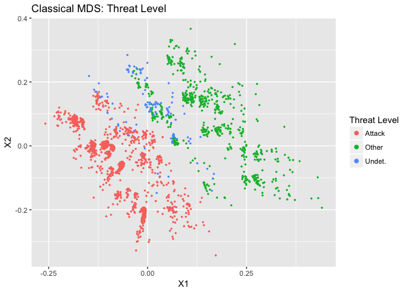

colored by race

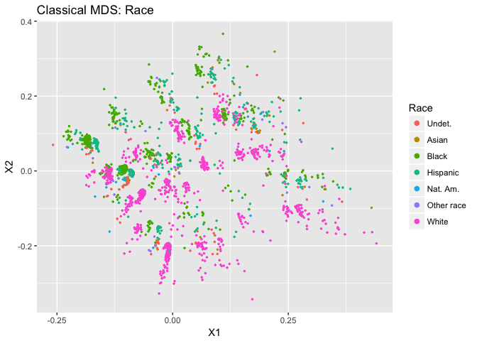

colored by body camera

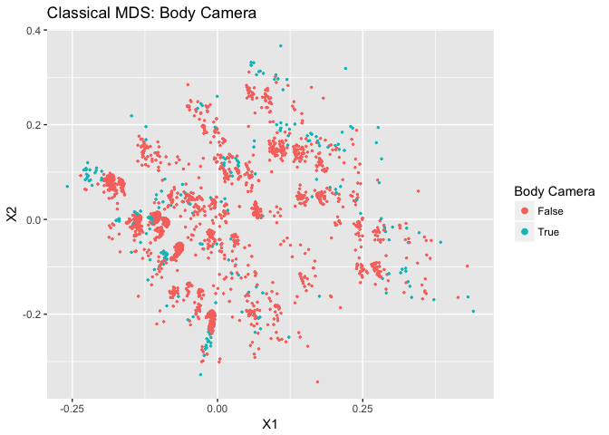

### RACE IN FATAL SHOOTINGS

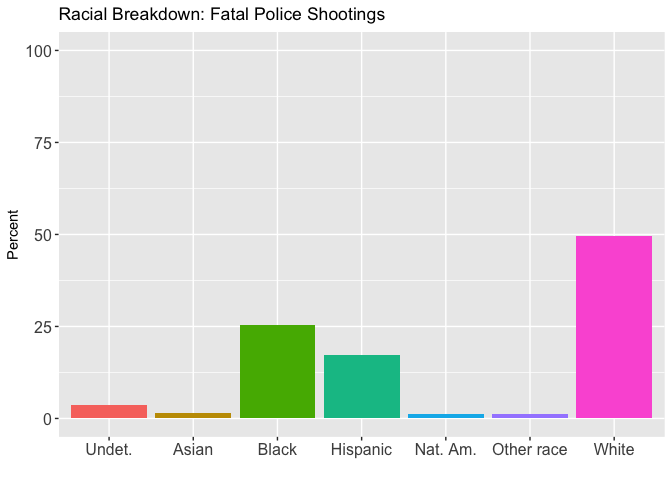

### RACE IN THE US

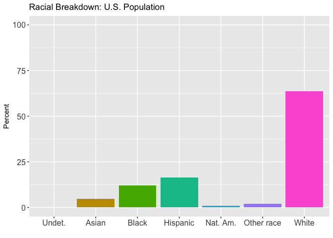

### RACE AND WEAPON

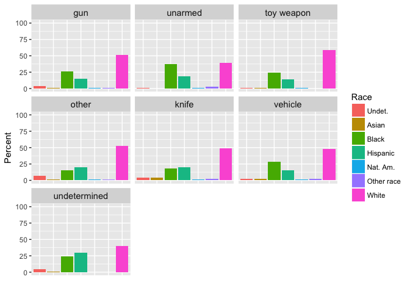

### RACE AND THREAT LEVEL

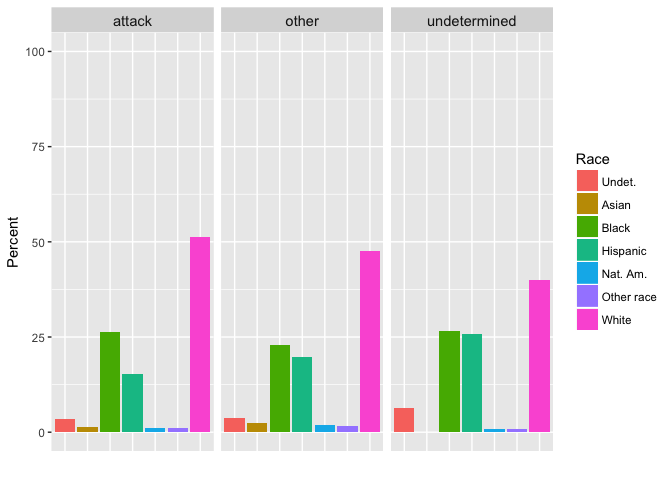

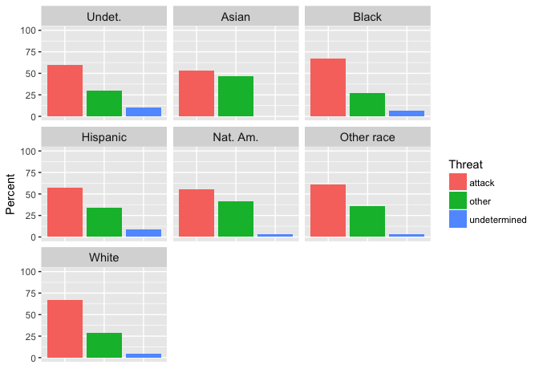

### RACE AND MENTAL ILLNESS

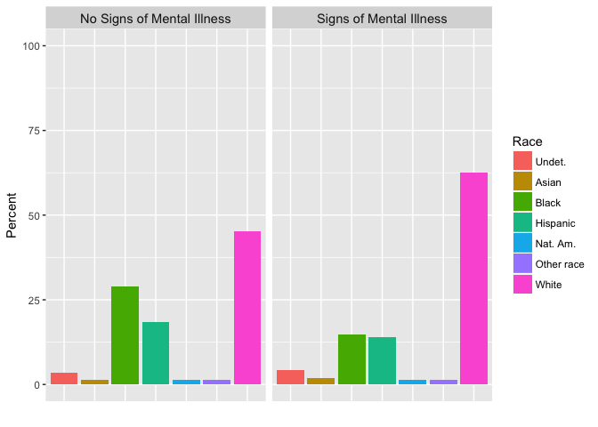

### RACE AND BODY CAMERA

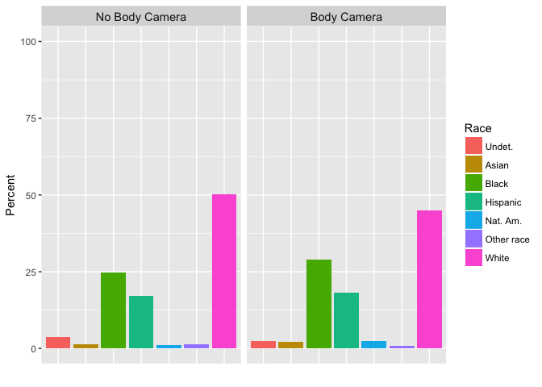

### RACE AND FLEEING

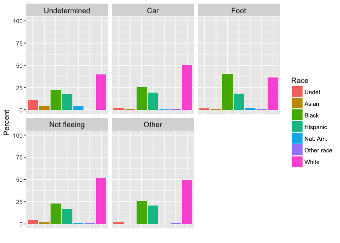

## Kidus

load in shared data with Laura, Zoe and Ed

Clean up the data to remove duplicate entries.

There were many different kinds of weapons that were only mentioned once, and others that were combined categories, so we chose to simplify. We created new categories "gun", "knife", "vehicle", "undetermined", "toy weapon", "unarmed", and "other"

We were interested in any regional effects, so we subdivided the state into 'Northeast', 'Midwest', 'South', 'West'.

Split up our data into train and test set

set the seed to make the partition reproducible

Train Gaussian SVM on full training set.

```
##                 Y.train
## g.svm.pred.train   O   W   B
##                O 205  91  52
##                W 197 653 205
##                B  25  59 146

## [1] 0.6148194
```

0.6148194 Test Gaussian SVM on full test set

```
##           Y.test
## g.svm.pred   O   W   B
##          O  62  31  18
##          W  51 218  79
##          B   8  27  51

## [1] 0.6073394
```

0.6073394 POLY SVM Polynomial kernel Train Poly SVM on full training set

```
##                 Y.train
## g.svm.pred.train   O   W   B
##                O 206  95  53
##                W 198 648 212
##                B  23  60 138

## [1] 0.6074709
```

0.6074709 Test Poly SVM on full test set

```
##           Y.test
## g.svm.pred   O   W   B
##          O  59  30  16
##          W  55 215  82
##          B   7  31  50

## [1] 0.5944954
```

0.5944954 Linear kernel Train Gaussian SVM on full training set

```
##                 Y.train
## g.svm.pred.train   O   W   B
##                O 204 112  52
##                W 195 601 204
##                B  28  90 147

## [1] 0.5829761
```

0.5829761 Test Gaussian SVM on full test set

```
##           Y.test
## g.svm.pred   O   W   B
##          O  61  32  18
##          W  51 210  77
##          B   9  34  53

## [1] 0.5944954
```

0.5944954 Train Multinomial Logistic Regression on full training set

```
##                   Y.train
## m.log.r.pred.train   O   W   B
##                  O 184 103  44
##                  W 202 594 201
##                  B  41 106 158

## [1] 0.5731782
```

0.5731782 Test Multinomial Logistic Regression on full test set

```
##             Y.test
## m.log.r.pred   O   W   B
##            O  53  26  13
##            W  56 213  77
##            B  12  37  58

## [1] 0.5944954
```

0.5944954

### BY REGION

#### REGION 1 - NORTHEAST

split up our data into train and test set

Train Gaussian SVM on region

```
##                 Y.train
## g.svm.pred.train  O  W  B
##                O  5  1  0
##                W  7 48  8
##                B  9  9 36

## [1] 0.7235772
```

0.7235772 Test Gaussian SVM on region

```
##           Y.test
## g.svm.pred  O  W  B
##          O  0  2  0
##          W  3 12  5
##          B  4  4 11

## [1] 0.5609756
```

0.5609756

#### REGION 2 - MIDWEST

split up our data into train and test set

Train Gaussian SVM on region

```
##                 Y.train
## g.svm.pred.train   O   W   B
##                O  26   0   0
##                W   4 152   5
##                B   2   5  77

## [1] 0.9409594
```

0.9409594 Test Gaussian SVM on region

```
##           Y.test
## g.svm.pred  O  W  B
##          O  0  4  3
##          W  4 35 15
##          B  1  7 22

## [1] 0.6263736
```

0.6263736 #### REGION 3 - SOUTH

split up our data into train and test set

Train Gaussian SVM on region

```
##                 Y.train
## g.svm.pred.train   O   W   B
##                O  66   3   4
##                W  33 349  55
##                B   4  15 145

## [1] 0.8308605
```

0.8308605 Test Gaussian SVM on region

```
##           Y.test
## g.svm.pred  O  W  B
##          O 15  8  6
##          W 19 84 36
##          B  4 19 34

## [1] 0.5911111
```

0.5911111 #### REGION 4 - WEST

split up our data into train and test set

Train Gaussian SVM on region

```
##                 Y.train
## g.svm.pred.train   O   W   B
##                O 215  35  17
##                W  38 210  14
##                B   2   0  33

## [1] 0.8120567
```

0.8120567 Test Gaussian SVM on region

```
##           Y.test
## g.svm.pred  O  W  B
##          O 53 26 14
##          W 27 46 10
##          B  7  5  1

## [1] 0.5291005
```

0.5291005 ### FEATURE SELECTION set the seed to make the partition reproducible EXCLUDE REGION FOR THIS PART

define the control using a random forest selection function

run the RFE algorithm

summarize the results

```
##
## Recursive feature selection
##
## Outer resampling method: Cross-Validated (10 fold)
##
## Resampling performance over subset size:
##
##  Variables Accuracy  Kappa AccuracySD KappaSD Selected
##          1   0.5230 0.2462    0.02906 0.05262
##          2   0.5462 0.2605    0.04939 0.07722
##          3   0.5708 0.2954    0.02759 0.04567
##          4   0.5690 0.2946    0.04643 0.07543
##          5   0.5713 0.2939    0.03917 0.06454
##          6   0.5848 0.3130    0.02501 0.04204
##          7   0.5897 0.3165    0.02767 0.04469        *
##          8   0.5891 0.3132    0.02924 0.04623
##         10   0.5799 0.3053    0.03477 0.05571
##
## The top 5 variables (out of 7):
##    lon, age, lat, signs_of_mental_illness, weapon_cat
```

list the chosen features

```
## [1] "lon"                     "age"
## [3] "lat"                     "signs_of_mental_illness"
## [5] "weapon_cat"              "threat_level"
## [7] "gender"
```

plot the results

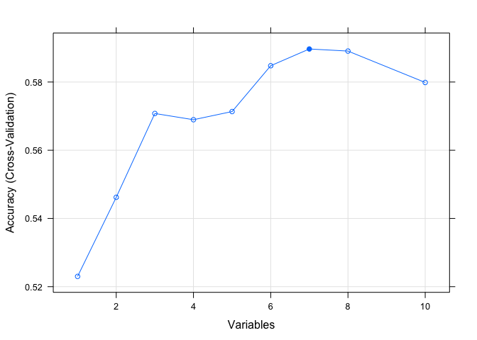

in light of the above let us only use lon, age, lat, mental illness, threat, gender, weapon_cat

RFE TRAIN

```
##                 Y.train
## g.svm.pred.train   O   W   B
##                O 209  82  50
##                W 195 662 203
##                B  23  59 150

## [1] 0.6252296
```

0.6252296 RFE TEST

```
##           Y.test
## g.svm.pred   O   W   B
##          O  57  28  16
##          W  58 222  83
##          B   6  26  49

## [1] 0.6018349
```

0.6018349 ### LAT - LONG INTERACTION TERM

RFE TRAIN

```
##                 Y.train
## g.svm.pred.train   O   W   B
##                O 208  75  47
##                W 194 664 198
##                B  25  64 158

## [1] 0.630741
```

```
##           Y.test
## g.svm.pred   O   W   B
##          O  60  26  17
##          W  55 223  76
##          B   6  27  55

## [1] 0.6201835
```

REGION 1 - NORTHEAST

split up our data into train and test set

Train Gaussian SVM on region

```
##                 Y.train
## g.svm.pred.train  O  W  B
##                O  5  1  0
##                W  8 50 10
##                B  8  7 34

## [1] 0.7235772
```

0.7235772 Test Gaussian SVM on region

```
##           Y.test
## g.svm.pred  O  W  B
##          O  0  1  0
##          W  3 15  6
##          B  4  2 10

## [1] 0.6097561
```

0.6097561

#### REGION 2 - MIDWEST

split up our data into train and test set

Train Gaussian SVM on region

```
##                 Y.train
## g.svm.pred.train   O   W   B
##                O  21   1   0
##                W   6 145   9
##                B   5  11  73

## [1] 0.8819188
```

0.8819188 Test Gaussian SVM on region

```
##           Y.test
## g.svm.pred  O  W  B
##          O  0  6  1
##          W  4 31 21
##          B  1  9 18

## [1] 0.5384615
```

0.5384615 #### REGION 3 - SOUTH

split up our data into train and test set

Train Gaussian SVM on region

```
##                 Y.train
## g.svm.pred.train   O   W   B
##                O  42   3   3
##                W  54 349  77
##                B   7  15 124

## [1] 0.764095
```

0.764095 Test Gaussian SVM on region

```
##           Y.test
## g.svm.pred  O  W  B
##          O 14  6  3
##          W 19 87 48
##          B  5 18 25

## [1] 0.56
```

0.56 ### REGION 4 - WEST

split up our data into train and test set

Train Gaussian SVM on region

```
##                 Y.train
## g.svm.pred.train   O   W   B
##                O 208  57  34
##                W  46 187  14
##                B   1   1  16

## [1] 0.7287234
```

0.7287234 Test Gaussian SVM on region

```
##           Y.test
## g.svm.pred  O  W  B
##          O 61 32 17
##          W 24 45  6
##          B  2  0  2

## [1] 0.5714286
```

0.5714286

## Ed

### Data Analysis

construct the oversampled training set

fit random forest and calculate cv error

```
## [[1]]
## [1] 314.8
##
## [[2]]
## [1] 0.9291268
```

same as above for undersampled training set

```
## [[1]]
## [1] 275
##
## [[2]]
## [1] 0.3993785
```

For regular training set, search for optimal k

```
## [1]   0.001 298.280
## [1]   0.01 287.76
## [1]   0.10 268.92
## [1]   0.25 308.48
## [1]   0.50 326.36

## [1]   0.10 270.88
## [1]   0.11 278.80
## [1]   0.12 274.92
## [1]   0.13 274.52
## [1]   0.14 278.52
## [1]   0.15 284.68
## [1]   0.16 282.32
## [1]   0.17 288.64
## [1]   0.18 291.12
## [1]   0.19 290.68
## [1]   0.20 296.48

## [[1]]
##
##         False True
##   False   255   22
##   True    189   34
##
## [[2]]
## [1] 0.4256757
##
## [[3]]
## [1] 0.3928571
##
## [[4]]
## [1] 387

## [[1]]
##
##         False True
##   False  1388    0
##   True    107  182
##
## [[2]]
## [1] 0.07157191
##
## [[3]]
## [1] 0
##
## [[4]]
## [1] 107
```

For oversampled training set, search for optimal k

```
## [1]   0.001 298.800
## [1]   0.01 293.16
## [1]   0.10 273.48
## [1]   0.25 275.32
## [1]   0.5 316.6

## [1]   0.10 271.28
## [1]   0.11 268.68
## [1]   0.12 266.40
## [1]   0.13 268.84
## [1]   0.14 270.08
## [1]   0.15 261.64
## [1]   0.16 267.60
## [1]   0.17 264.08
## [1]   0.18 270.16
## [1]   0.19 273.80
## [1]   0.20 274.88

## [[1]]
##
##         False True
##   False   257   23
##   True    187   33
##
## [[2]]
## [1] 0.4211712
##
## [[3]]
## [1] 0.4107143
##
## [[4]]
## [1] 394

## [[1]]
##
##         False True
##   False  1315    0
##   True    180 1495
##
## [[2]]
## [1] 0.1204013
##
## [[3]]
## [1] 0
##
## [[4]]
## [1] 180
```

For undersampled training set, search for optimal k

```
## [1]   0.001 299.000
## [1]   0.01 299.00
## [1]   0.10 298.08
## [1]   0.25 288.00
## [1]   0.5 276.2

## [1]   0.4 269.0
## [1]   0.41 265.40
## [1]   0.42 261.20
## [1]   0.43 271.68
## [1]   0.44 267.80
## [1]   0.45 265.76
## [1]   0.46 270.52
## [1]   0.47 268.52
## [1]   0.48 278.04
## [1]   0.49 266.96
## [1]   0.50 278.04

## [[1]]
##
##         False True
##   False   182    0
##   True      0  182
##
## [[2]]
## [1] 0
##
## [[3]]
## [1] 0
##
## [[4]]
## [1] 0
```